# Una Recuperación en Ciernes: Reactivación Económica e Inflación

La propagación del Covid-19 significó en el mundo una crisis sin precedentes. Sin embargo, las medidas extraordinarias de estímulo económico que optaron rápidamente los países ayudaron a establecer un escenario favorable para la recuperación de las economías; no obstante, esta recuperación aún no es definitiva y se encuentra sujeta a riesgos (contexto político, ejecución de políticas económicas y evolución de nuevas variantes del COVID-19) que pueden revertir dicha evolución.

[figure not shown]

[figure not shown]

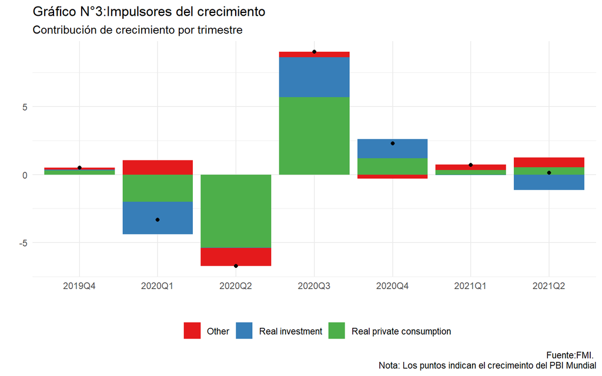

[figure not shown]

[figure not shown]

Por otra parte, en los últimos meses se ha observado una fuerte depreciación y variabilidad del sol frente al dólar. Ello tendría origen principalmente en factores idiosincráticos. Por ejemplo, el contexto político ha sido una constante que ha gatillado dicha situación en muchos países. Este factor ha contribuido al alza del precio principalmente por dos canales. El primer canal (el más directo) es a través del aumento de los bienes importados. Mientras el segundo canal, se debe al incremento del precio de insumos importados que se transfiere al bien final que es comprado por el consumir.

Finalmente, países con una economía pequeña y abierta también se encuentran sujetas a factores externos como las condiciones financieras mundiales. Por lo que también ha sido determinante la evolución de la inflación de economías avanzadas y decisiones de política de otros países en la inflación local de los países.

Por lo tanto, según lo anterior, los aumentos de precios, no solo son consecuencia de un factor sino que provienen tanto del lado de la oferta como el de la demanda y del contexto que atraviesa el país. Para que esta situación se alivie y la persistencia de las presiones inflacionarias no se materialicen en mayores desequilibrios macroeconómicos, el accionar de las autoridades de política económica será fundamental, ya que, hasta el momento, no hay un panorama claro de que los factores sean transitorios y de que la economía podría retornar a una senda de equilibrio.

Al respecto para que se dé el caso en el cual los factores se disipen y las presiones inflacionarias se reviertan (escenario ideal) se debería suponer que las presiones de la demanda irán disminuyendo, que la demanda se rebalanceará desde bienes a servicios, que las políticas expansivas en respuesta de la pandemia se puedan revertir con facilidad y las expectativas se encuentren bien ancladas (BCCH, 2021). Sin embargo, como se ha venido observando en el contexto actual, y como se ha mencionado anteriormente, estos supuestos no son un hecho claro. Por lo que las autoridades deberán sopesar en sus decisiones: (i) no perjudicar la recuperación en transcurso de la economía y (ii) mitigar los efectos de la inflación en la actividad económica.

## Referencias

BCCH. (2021, 19 de octubre). IMF High-level Policy Panel “Inflation Scares” Remarks [Nota de prensa]. https://www.bcentral.cl/documents/33528/133214/mmc19102021.pdf/3408dc39- 7e4d-fc63-007d-eb838d649b60?t=1634684132760

BCRP. (2021). Reporte de inflación Setiembre 2021: Panorama actual y proyecciones macroeconómica 2021-2022.https://www.bcrp.gob.pe/docs/Publicaciones/Reporte-Inflacion/2021/setiembre/reporte-de-inflacion-setiembre-2021.pdf

IMF. (2021). World Economic Outlook.

Winkelried, D. (2012). Traspaso del tipo de cambio y metas de inflación en el Perú. Banco Central de Reserva del Perú. Revista Estudios Económicos, 23, 9-24.